# Simulation exercise in **Genomik und Bioinformatik**

# Estimating $\pi$

$\pi$ is a number that can be used to compute the area of a circle. The unit circle is the circle with radius 1. In order to approximate $\pi$, we can generate uniformly distributed random points in a square of length and height 1. By counting the number of points which are within the unit circle and dividing this number by all points generated, we can approximate $\pi/4$.

### 1. R script to estimate $\pi$

Write a script in R that approximates $\pi$ as described above. Randomly generate 1000 points in the unit square and estimate $\pi$.

**Answer:** $\pi$ can be estimated as follows:

```r
> num.samples <- 1000
> rand_points <- matrix(runif(2 * num.samples), ncol=2)
> dist <- sqrt((rand_points[, 1])^2 + (rand_points[, 2])^2)
> in.circle <- ifelse(dist <= 1, TRUE, FALSE)
> pi.estimate <- 4 * sum(in.circle) / num.samples
```

**Question (a):** Is `runif` or `rnorm` the better choice to generate uniformly distributed random points in the unit square? Why?

**Answer:** `rnorm` generates random numbers according to a normal distribution. I.e., many points related to normal destributed random numbers are close to the origin of the unit square, while only a few such points are far away. Hence, this is not the proper distribution for uniformly distributed points in the unit square. On the other hand, `runif` with the two parameters 0 and 1 generates uniformly distributed random numbers between 0 and 1. Points that are formed of two such numbers, are uniformly distributed in the unit square.

**Question (b):** For illustration, generate a plot that shows random points within the unit circle in red and random points outside the unit circle in blue. Why is this plot useful?

**Answer:** The plot allows visual control of the script and illustrates how $\pi$ is estimated:

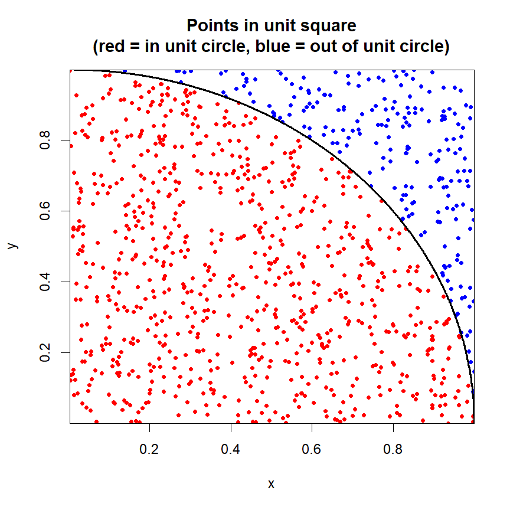

Estimate pi in a unit square by simulation.

```r
> cols <- ifelse(in.circle, "red", "blue")
> plot(rand_points[, 1], rand_points[, 2], col=cols, xlab="x", ylab="y", pch=20, xaxs="i", yaxs="i",
+      main="Points in unit square\n(red = in unit circle, blue = out of unit circle)")
> x <- seq(0, 1, 0.001)
> lines(x, sqrt(1 - x^2), lwd=2)
```

**Question (c):** How close is the estimation to the correct value, if you use 1000 random points? Is the result the same, if you re-run your script? Explain the observed behavior.

**Answer:** The estimation is pretty close to the correct value (estimated: 3.144, correct: 3.1415927, absolute difference: 0.0024073, relative difference: 1.0007663). In this case, re-running the .Rmd script yields the same results because the seed of the random number generator is set to a fixed value at the beginning of the .Rmd script. If the seed was not set at the beginning the result would differ.

### 2. Precision improvement by increasing the number of samples

Go through the tasks below to approximate $\pi$ 100 times using 100 samples, 100 times using 1000 samples and 100 times using 10,000 samples.

**Question (a):** Write a function to approximate $\pi$ as described above. The function should take the number of points as argument and return the estimate.

**Answer:** The function to describe $\pi$ is as follows:

```r
> myApprox <- function(N=1000){
+   x <- runif(N)
+   y <- runif(N)
+   circle <- y <= sqrt(1 - x**2)
+   counts <- length(which(circle))
+   p <-(counts/N)*4
+
+   return(p)
+ }
> myApprox()
```

```
## [1] 3.088
```

**Question (b)**: Create a 100 x 3 matrix to store the estimates from the single runs of the function.

**Answer:** Preallocate the required space for the matrix:

```r
> myMatrix <- matrix(0, nrow  = 100, ncol = 3)
```

**Question (c)**: Use the `for` construct to generate two nested loops in R. The inner loop is used to re-run $\pi$-estimation 100 times using the same parameter (e.g. number of samples per estimation). The outer loop is used to perform the inner loop using different number of samples. Fill the matrix with the estimates.

**Answer:** Fill the matrix:

```r
> samples <- c(100, 1000, 10000)
> for (n in seq_along(samples)) {
+   for (m in 1:100) {
+     myMatrix[m, n] <- myApprox(samples[n])
+   }
+ }
```

**Question (d)**: Use the function `summary` to report the results for different sample sizes. What is shown in the output of `summary` under `'1st Qu'` and `'3rd Qu'`?

```r
> summary(myMatrix)
```

```
##        V1              V2              V3
##  Min.   :2.680   Min.   :3.024   Min.   :3.106
##  1st Qu.:3.040   1st Qu.:3.104   1st Qu.:3.133
##  Median :3.120   Median :3.132   Median :3.141
##  Mean   :3.134   Mean   :3.138   Mean   :3.142
##  3rd Qu.:3.200   3rd Qu.:3.173   3rd Qu.:3.153
##  Max.   :3.560   Max.   :3.244   Max.   :3.183
```

**Question (e)**: The function `summary` shows averages and extremes etc. of a distribution. Alternatively, A distribution can be illustrated by a histogram. Use the function `hist` to visualize the distributions of $\pi$-estimations for different sample sizes. How can you use the plotting parameter `mfrow` to show the histograms for different parameters one above the other in the same plot? (Hint: `help(par)`) Use the same range on the x axis for every histogram to make the visual comparison of the plots easier. Use a reasonable number of breaks in the histograms. Mark the true value of $\pi$ with a vertical red line in every histogram and use `mtext` to add labels to these lines.

**Answer:** Following the instructions above we get the histograms with the following code:

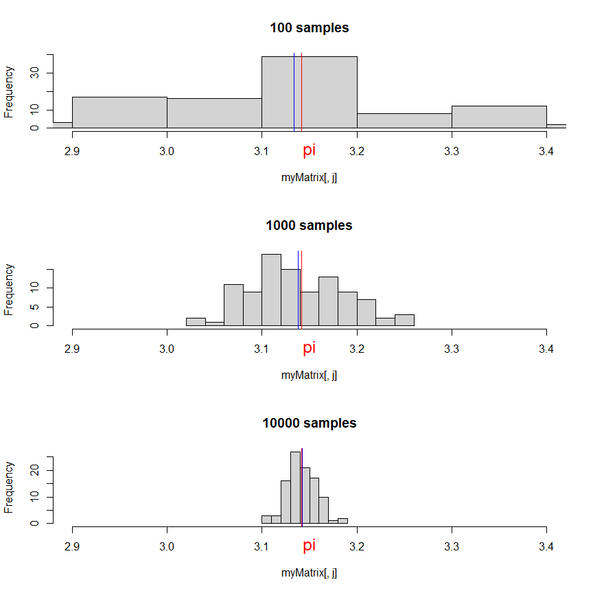

```r
> N <- c(100, 1000, 10000)
> myDimensions <- dim(myMatrix)
> myColumns <- myDimensions[2]
>
> par(mfrow=c(myColumns,1))
> for (j in seq(1, myColumns)){
+   hist(myMatrix[, j], main=paste((N[j]), "samples"), xlim=c(2.9,3.4))
+   abline(v=mean(myMatrix[, j]), col="blue")
+   abline(v=pi, col="red")
+   mtext("pi", side = 1, col = "red", line = 1)
+ }
```